# EPS: alcohol consumption transitions, version 4

Recovery of observed C3plus and C4 (C4 is a tail diagnostic only)

| model | outcome | sex | n | observed | predicted | ratio_P_over_O | difference_P_minus_O | lower | upper |
| --- | --- | --- | --- | --- | --- | --- | --- | --- | --- |
| Lognormal | C3plus, all pairs | All | 8167 | 0.0142 | 0.0108 | 0.7632 | -0.0034 | -0.0064 | -0.0003 |
| Lognormal | C3plus, all pairs | Men | 3152 | 0.0228 | 0.0170 | 0.7462 | -0.0058 | -0.0116 | 0.0000 |
| Lognormal | C3plus, all pairs | Women | 5015 | 0.0063 | 0.0051 | 0.8201 | -0.0011 | -0.0038 | 0.0015 |
| Lognormal | C4 diagnostic, all pairs | All | 8167 | 0.0048 | 0.0035 | 0.7376 | -0.0012 | -0.0030 | 0.0005 |
| Lognormal | C4 diagnostic, all pairs | Men | 3152 | 0.0076 | 0.0053 | 0.6926 | -0.0023 | -0.0056 | 0.0009 |
| Lognormal | C4 diagnostic, all pairs | Women | 5015 | 0.0022 | 0.0019 | 0.8815 | -0.0003 | -0.0016 | 0.0011 |
| Gamma | C3plus, all pairs | All | 8167 | 0.0142 | 0.0081 | 0.5753 | -0.0060 | -0.0091 | -0.0029 |
| Gamma | C3plus, all pairs | Men | 3152 | 0.0228 | 0.0144 | 0.6329 | -0.0084 | -0.0143 | -0.0024 |
| Gamma | C3plus, all pairs | Women | 5015 | 0.0063 | 0.0024 | 0.3827 | -0.0039 | -0.0066 | -0.0012 |
| Gamma | C4 diagnostic, all pairs | All | 8167 | 0.0048 | 0.0012 | 0.2502 | -0.0036 | -0.0053 | -0.0018 |
| Gamma | C4 diagnostic, all pairs | Men | 3152 | 0.0076 | 0.0020 | 0.2696 | -0.0055 | -0.0088 | -0.0023 |
| Gamma | C4 diagnostic, all pairs | Women | 5015 | 0.0022 | 0.0004 | 0.1878 | -0.0018 | -0.0031 | -0.0004 |
| Lognormal_sexage | C3plus, all pairs | All | 8167 | 0.0142 | 0.0112 | 0.7912 | -0.0030 | -0.0060 | 0.0001 |
| Lognormal_sexage | C3plus, all pairs | Men | 3152 | 0.0228 | 0.0184 | 0.8078 | -0.0044 | -0.0102 | 0.0014 |
| Lognormal_sexage | C3plus, all pairs | Women | 5015 | 0.0063 | 0.0046 | 0.7358 | -0.0017 | -0.0043 | 0.0010 |
| Lognormal_sexage | C4 diagnostic, all pairs | All | 8167 | 0.0048 | 0.0037 | 0.7834 | -0.0010 | -0.0027 | 0.0007 |
| Lognormal_sexage | C4 diagnostic, all pairs | Men | 3152 | 0.0076 | 0.0060 | 0.7882 | -0.0016 | -0.0048 | 0.0016 |
| Lognormal_sexage | C4 diagnostic, all pairs | Women | 5015 | 0.0022 | 0.0017 | 0.7680 | -0.0005 | -0.0019 | 0.0009 |
| Lognormal_Pareto | C3plus, all pairs | All | 8167 | 0.0142 | 0.0123 | 0.8718 | -0.0018 | -0.0048 | 0.0012 |
| Lognormal_Pareto | C3plus, all pairs | Men | 3152 | 0.0228 | 0.0194 | 0.8508 | -0.0034 | -0.0092 | 0.0024 |
| Lognormal_Pareto | C3plus, all pairs | Women | 5015 | 0.0063 | 0.0059 | 0.9420 | -0.0004 | -0.0030 | 0.0023 |
| Lognormal_Pareto | C4 diagnostic, all pairs | All | 8167 | 0.0048 | 0.0055 | 1.1485 | 0.0007 | -0.0010 | 0.0024 |
| Lognormal_Pareto | C4 diagnostic, all pairs | Men | 3152 | 0.0076 | 0.0083 | 1.0978 | 0.0007 | -0.0025 | 0.0040 |
| Lognormal_Pareto | C4 diagnostic, all pairs | Women | 5015 | 0.0022 | 0.0028 | 1.3106 | 0.0007 | -0.0007 | 0.0020 |
| Hurdle_Pareto | C3plus, all pairs | All | 8167 | 0.0142 | 0.0142 | 1.0019 | 0.0000 | -0.0030 | 0.0031 |
| Hurdle_Pareto | C3plus, all pairs | Men | 3152 | 0.0228 | 0.0230 | 1.0105 | 0.0002 | -0.0055 | 0.0060 |
| Hurdle_Pareto | C3plus, all pairs | Women | 5015 | 0.0063 | 0.0061 | 0.9732 | -0.0002 | -0.0029 | 0.0026 |
| Hurdle_Pareto | C4 diagnostic, all pairs | All | 8167 | 0.0048 | 0.0044 | 0.9229 | -0.0004 | -0.0021 | 0.0013 |
| Hurdle_Pareto | C4 diagnostic, all pairs | Men | 3152 | 0.0076 | 0.0073 | 0.9638 | -0.0003 | -0.0035 | 0.0029 |
| Hurdle_Pareto | C4 diagnostic, all pairs | Women | 5015 | 0.0022 | 0.0017 | 0.7923 | -0.0005 | -0.0018 | 0.0009 |
| Hurdle_Pareto_ridge | C3plus, all pairs | All | 8167 | 0.0142 | 0.0142 | 1.0015 | 0.0000 | -0.0030 | 0.0030 |
| Hurdle_Pareto_ridge | C3plus, all pairs | Men | 3152 | 0.0228 | 0.0215 | 0.9431 | -0.0013 | -0.0071 | 0.0045 |
| Hurdle_Pareto_ridge | C3plus, all pairs | Women | 5015 | 0.0063 | 0.0075 | 1.1970 | 0.0012 | -0.0015 | 0.0040 |
| Hurdle_Pareto_ridge | C4 diagnostic, all pairs | All | 8167 | 0.0048 | 0.0044 | 0.9166 | -0.0004 | -0.0021 | 0.0013 |
| Hurdle_Pareto_ridge | C4 diagnostic, all pairs | Men | 3152 | 0.0076 | 0.0068 | 0.8993 | -0.0008 | -0.0040 | 0.0024 |
| Hurdle_Pareto_ridge | C4 diagnostic, all pairs | Women | 5015 | 0.0022 | 0.0021 | 0.9720 | -0.0001 | -0.0014 | 0.0013 |
| A | C3plus, all pairs | All | 8167 | 0.0142 | 0.0148 | 1.0434 | 0.0006 | -0.0023 | 0.0036 |
| A | C3plus, all pairs | Men | 3152 | 0.0228 | 0.0218 | 0.9581 | -0.0010 | -0.0067 | 0.0048 |
| A | C3plus, all pairs | Women | 5015 | 0.0063 | 0.0083 | 1.3287 | 0.0021 | -0.0007 | 0.0048 |

Mean grams/day among C3plus destinations, truncated at 150 g/day

| model | sex | predicted_mean_grams_C3plus | observed_mean_grams_C3plus | n_observed | observed_above_cap |
| --- | --- | --- | --- | --- | --- |
| Lognormal | All | 78.6 | 77.1 | 93 | 9 |
| Lognormal | Men | 85.2 | 83.8 | 64 | 9 |
| Lognormal | Women | 60.3 | 58.2 | 29 | 0 |
| Gamma | All | 74.6 | 77.1 | 93 | 9 |
| Gamma | Men | 78.9 | 83.8 | 64 | 9 |
| Gamma | Women | 51.4 | 58.2 | 29 | 0 |
| Lognormal_sexage | All | 79.7 | 77.1 | 93 | 9 |
| Lognormal_sexage | Men | 85.7 | 83.8 | 64 | 9 |
| Lognormal_sexage | Women | 59.8 | 58.2 | 29 | 0 |
| Lognormal_Pareto | All | 81.3 | 77.1 | 93 | 9 |
| Lognormal_Pareto | Men | 87.6 | 83.8 | 64 | 9 |
| Lognormal_Pareto | Women | 64.8 | 58.2 | 29 | 0 |
| Hurdle_Pareto | All | 77.5 | 77.1 | 93 | 9 |
| Hurdle_Pareto | Men | 84.4 | 83.8 | 64 | 9 |
| Hurdle_Pareto | Women | 56.2 | 58.2 | 29 | 0 |
| Hurdle_Pareto_ridge | All | 75.9 | 77.1 | 93 | 9 |
| Hurdle_Pareto_ridge | Men | 84.4 | 83.8 | 64 | 9 |
| Hurdle_Pareto_ridge | Women | 56.2 | 58.2 | 29 | 0 |

Randomized PIT: all destination drinkers and the tail above the training 90th percentile

| model | subset | n | mean_U | share_U_above_0.9 | weighted_KS |
| --- | --- | --- | --- | --- | --- |
| Lognormal | all drinkers | 3013 | 0.494 | 0.103 | 0.024 |
| Lognormal | tail above training q90 | 293 | 0.565 | 0.140 | 0.107 |
| Gamma | all drinkers | 3013 | 0.466 | 0.095 | 0.092 |
| Gamma | tail above training q90 | 293 | 0.648 | 0.307 | 0.226 |
| Lognormal_sexage | all drinkers | 3013 | 0.494 | 0.102 | 0.025 |
| Lognormal_sexage | tail above training q90 | 293 | 0.563 | 0.140 | 0.100 |
| Lognormal_Pareto | all drinkers | 3013 | 0.494 | 0.105 | 0.024 |
| Lognormal_Pareto | tail above training q90 | 293 | 0.537 | 0.075 | 0.110 |
| Hurdle_Pareto | all drinkers | 3013 | 0.490 | 0.096 | 0.027 |
| Hurdle_Pareto | tail above training q90 | 293 | 0.542 | 0.148 | 0.075 |
| Hurdle_Pareto_ridge | all drinkers | 3013 | 0.490 | 0.098 | 0.027 |
| Hurdle_Pareto_ridge | tail above training q90 | 293 | 0.537 | 0.112 | 0.079 |

Pre-registered adoption rule

| model | C3plus_abs_log_ratio | lognormal_abs_log_ratio | rule1_C3plus_calibration | rule2_logloss_not_worse | rule3_no_new_cell_bias | eligible | max_abs_cell_difference | C4_abs_log_ratio | grams_cell_logscore |
| --- | --- | --- | --- | --- | --- | --- | --- | --- | --- |
| Gamma | 0.553 | 0.27 | FALSE | FALSE | FALSE | FALSE | 0.073 | 1.386 | 3.616 |
| Lognormal_sexage | 0.234 | 0.27 | FALSE | TRUE | TRUE | FALSE | 0.064 | 0.244 | 3.484 |
| Lognormal_Pareto | 0.137 | 0.27 | TRUE | TRUE | TRUE | TRUE | 0.069 | 0.138 | 3.485 |
| Hurdle_Pareto | 0.002 | 0.27 | TRUE | TRUE | TRUE | TRUE | 0.029 | 0.080 | 3.488 |

```
Adopted amount model: Hurdle_Pareto
```

C3plus destinations by sex and age (events behind the hurdle logistic)

| sex | age_group | C3plus_destinations |
| --- | --- | --- |
| Men | 18-29 | 45 |
| Women | 18-29 | 23 |
| Men | 30-44 | 11 |
| Women | 30-44 | 5 |
| Men | 45-59 | 11 |
| Women | 45-59 | 1 |
| Men | 60-65 | 6 |
| Women | 60-65 | 0 |

Hurdle coefficients above 5 in absolute value (quasi-separation)

| term | coefficient |
| --- | --- |
| edu_missing | -14.976 |
| sexWomen:age_group60-65 | -13.578 |

```
Elapsed: 0.91 minutes
```

**How to read the decision.** The hurdle mixture fits a logistic model directly to the C3plus indicator, so its pooled C3plus calibration is close to exact by construction. What separates it from the lognormal with a Pareto tail is the cell-level error. The unpenalised hurdle logistic is quasi-separated: women aged 60–65 have no C3plus destination, and the education-missing indicator is nearly empty. It therefore assigns a C3plus probability close to zero to those cells, which would be a structural zero in a microsimulation. A ridge-penalised hurdle is reported as a declared sensitivity. It was added after the pre-registered comparison and is not eligible for adoption. Any Pareto tail is truncated at 150 g/day when grams are drawn.

## Final five-state matrices

**Show R code**

```r
.t0 <- Sys.time()
# Final five-state matrices. A model is fitted on all v4 pairs (IPW refitted on the v4 risk set), its four-class
# predictions (NC, C1, C2, C3plus) are averaged with the pair weights within each origin and group, and NC is written
# to N0 for N0 origins and to FD otherwise (the history map: a drinker who stops is FD; N0 cannot become FD).
# Uncertainty: the v1 stratified jackknife (JKn) multipliers, with IPW, participation and amount models refitted in
# every replicate, as in v1/v2.
ep_v4_fit_full <- function(a, model) {
  a$state0 <- a$state0_5; a$y1 <- a$y1_5
  pm <- ep_binary_fit(a, as.numeric(a$y1 != "NC"), ep_v4_formula(), a$wn)
  dc <- a[a$y1 != "NC" & a$grams1 > 0, ]
  list(model = model, participation = pm, amount = ep_v4_amount_fit(dc, model))
}
ep_v4_predict <- function(o, b) { b$state0 <- b$state0_5; ep_v4_class_probs(ep_binary_prob(o$participation, b), o$amount, b)$P }
ep_v4_matrices <- function(d, P, model, by = c("period", "sex", "age_group")) {
  d$state0 <- d$state0_5; groups <- split(seq_len(nrow(d)), ep_key(d, by))
  do.call(rbind, lapply(groups, function(ii) {
    z <- d[ii, ]
    do.call(rbind, lapply(ep_v4_ST, function(st) {
      ix <- ii[as.character(d$state0[ii]) == st]; n <- sum(d$mult[ix] > 0)
      p4 <- if (length(ix) && sum(d$wn[ix]) > 0) colSums(P[ix, , drop = FALSE] * d$wn[ix]) / sum(d$wn[ix]) else rep(NA_real_, 4)
      p5 <- c(N0 = 0, FD = 0, p4[-1]); p5[if (st == "N0") 1 else 2] <- p4[1]
      data.frame(model = model, group = ep_key(z[1, ], by), z[rep(1, 5), by, drop = FALSE], from = st, to = ep_v4_ST,
        n_origin = n, estimate = if (n) p5 else NA_real_, structural = !(ep_v4_ST %in% c(if (st == "N0") "N0" else "FD", ep_v4_ST[3:5])),
        support = if (n == 0) "unobserved origin" else if (n < 30) "sparse" else "observed", row.names = NULL)
    }))
  }))
}
ep_v4_three <- function(d, P, model) {
  cols <- c("model", "group", "period", "sex", "age_group", "from", "to", "n_origin", "estimate", "structural", "support")
  a <- ep_v4_matrices(d, P, model, c("period", "sex", "age_group"))
  b <- ep_v4_matrices(d, P, model, c("sex", "age_group")); b$period <- "All"
  d$pooled <- "All"; cc <- ep_v4_matrices(d, P, model, "pooled"); cc$period <- "All"; cc$sex <- "All"; cc$age_group <- "All"
  x <- rbind(a[cols], b[cols], cc[cols]); x[] <- lapply(x, function(v) if (is.factor(v)) as.character(v) else v); x
}
ep_v4_final_matrices <- function(r, models, B = NULL) {
  targets <- function(rr) {
    d <- ep_v4_ipw(rr)
    do.call(rbind, lapply(models, function(m) ep_v4_three(d, ep_v4_predict(ep_v4_fit_full(d, m), d), m)))
  }
  point <- targets(r); key <- paste(point$model, point$group, point$from, point$to)
  M <- ep_des$multipliers; J <- if (is.null(B)) ncol(M) else min(B, ncol(M)); reps <- matrix(NA_real_, J, nrow(point))
  for (j in seq_len(J)) {
    rj <- r; rj$mult <- M[match(rj$id, ep_des$master$id), j]; tj <- targets(rj)
    stopifnot(identical(paste(tj$model, tj$group, tj$from, tj$to), key)); reps[j, ] <- tj$estimate
    if (j %% 10 == 0 || j == J) cat(sprintf("v4 JKn %d/%d\n", j, J))
  }
  # JKn variance needs every replicate; a truncated run (tests only) returns point estimates without intervals.
  if (J < ncol(M)) return(cbind(point, se = NA_real_, lower = NA_real_, upper = NA_real_, valid_replicates = J, interval_status = "test run: no interval"))
  cbind(point, ep_interval(point$estimate, reps))
}
cat(sprintf("Elapsed: %.2f minutes\n", as.numeric(difftime(Sys.time(), .t0, units = "mins"))))
```

```
Elapsed: 0.00 minutes
```

The matrices are fitted on all v4 pairs for the adopted model, the runner-up, the v1 lognormal and the ridge sensitivity. Intervals come from the v1 stratified jackknife, with IPW, participation and amount models refitted in every replicate. The last table compares the pooled v4 matrix with the v2 lognormal collapsed to five states.

**Show R code**

```r
.t0 <- Sys.time()
ep_v4_models_final <- unique(c(ep_v4_winner, "Lognormal_Pareto", "Lognormal", "Hurdle_Pareto_ridge"))
ep_v4_mat <- ep_v4_final_matrices(ep_v4_r9, ep_v4_models_final)
ep_save(ep_v4_mat, "v4_transition_matrices_design_CI")
rs <- stats::aggregate(estimate ~ model + group + from, ep_v4_mat[is.finite(ep_v4_mat$estimate), ], sum)
ep_check(max(abs(rs$estimate - 1)) < 1e-10, "Every v4 matrix row sums to one")
ep_check(all(ep_v4_mat$estimate[ep_v4_mat$structural & is.finite(ep_v4_mat$estimate)] == 0), "Structural zeros of the history map hold")
pooled <- ep_v4_mat[ep_v4_mat$group == "All", c("model", "from", "to", "n_origin", "estimate", "lower", "upper")]
ep_show(pooled[pooled$model == ep_v4_winner, ], paste("Pooled five-state matrix,", ep_v4_winner, "(JKn 95% intervals)"),
  paste("Pooled five-state matrix,", ep_v4_winner, "(JKn 95% intervals)"), 3)
# v2 versus v4 on the pooled matrix: the v2 Lognormal (official weight) collapsed to five states. Destinations C3 and
# C4 are summed within each origin; origins C3 and C4 are combined with their origin counts as weights.
v2 <- ep_v2_mat[ep_v2_mat$scheme == "official" & ep_v2_mat$model == "Lognormal" & ep_v2_mat$group == "All" & is.finite(ep_v2_mat$estimate), ]
v2$to <- ep_v4_merge(v2$to); v2 <- stats::aggregate(estimate ~ from + to + n_origin, v2, sum); v2$from <- ep_v4_merge(v2$from)
v2 <- do.call(rbind, lapply(split(v2, paste(v2$from, v2$to)), function(z)
  data.frame(from = z$from[1], to = z$to[1], estimate = stats::weighted.mean(z$estimate, z$n_origin))))
ep_v4_vs_v2 <- merge(v2, pooled[pooled$model == ep_v4_winner, c("from", "to", "estimate")], by = c("from", "to"), suffixes = c("_v2_lognormal", "_v4"))
ep_v4_vs_v2$change <- ep_v4_vs_v2$estimate_v4 - ep_v4_vs_v2$estimate_v2_lognormal
ep_save(ep_v4_vs_v2, "v4_vs_v2_pooled")
ep_show(ep_v4_vs_v2, "Pooled matrix: v2 (Lognormal, official weight, C3 + C4 summed) versus v4", "Pooled matrix: v2 (Lognormal, official weight, C3 + C4 summed) versus v4", 3)
cat(sprintf("Elapsed: %.2f minutes\n", as.numeric(difftime(Sys.time(), .t0, units = "mins"))))
```

```
v4 JKn 10/111
v4 JKn 20/111
v4 JKn 30/111
v4 JKn 40/111
v4 JKn 50/111
v4 JKn 60/111
v4 JKn 70/111
v4 JKn 80/111
v4 JKn 90/111
v4 JKn 100/111
v4 JKn 110/111
v4 JKn 111/111
```

Pooled five-state matrix, Hurdle_Pareto (JKn 95% intervals)

| model | from | to | n_origin | estimate | lower | upper |
| --- | --- | --- | --- | --- | --- | --- |
| Hurdle_Pareto | N0 | N0 | 4166 | 0.801 | 0.780 | 0.820 |
| Hurdle_Pareto | N0 | FD | 4166 | 0.000 | 0.000 | 0.000 |
| Hurdle_Pareto | N0 | C1 | 4166 | 0.188 | 0.170 | 0.208 |
| Hurdle_Pareto | N0 | C2 | 4166 | 0.006 | 0.004 | 0.007 |
| Hurdle_Pareto | N0 | C3plus | 4166 | 0.006 | 0.004 | 0.009 |
| Hurdle_Pareto | FD | N0 | 914 | 0.000 | 0.000 | 0.000 |
| Hurdle_Pareto | FD | FD | 914 | 0.625 | 0.577 | 0.670 |
| Hurdle_Pareto | FD | C1 | 914 | 0.355 | 0.309 | 0.403 |
| Hurdle_Pareto | FD | C2 | 914 | 0.012 | 0.009 | 0.015 |
| Hurdle_Pareto | FD | C3plus | 914 | 0.009 | 0.003 | 0.028 |
| Hurdle_Pareto | C1 | N0 | 2845 | 0.000 | 0.000 | 0.000 |
| Hurdle_Pareto | C1 | FD | 2845 | 0.389 | 0.361 | 0.417 |
| Hurdle_Pareto | C1 | C1 | 2845 | 0.560 | 0.532 | 0.587 |
| Hurdle_Pareto | C1 | C2 | 2845 | 0.030 | 0.027 | 0.033 |
| Hurdle_Pareto | C1 | C3plus | 2845 | 0.022 | 0.016 | 0.029 |
| Hurdle_Pareto | C2 | N0 | 150 | 0.000 | 0.000 | 0.000 |
| Hurdle_Pareto | C2 | FD | 150 | 0.392 | 0.303 | 0.490 |
| Hurdle_Pareto | C2 | C1 | 150 | 0.492 | 0.407 | 0.578 |
| Hurdle_Pareto | C2 | C2 | 150 | 0.071 | 0.051 | 0.098 |
| Hurdle_Pareto | C2 | C3plus | 150 | 0.045 | 0.022 | 0.088 |
| Hurdle_Pareto | C3plus | N0 | 92 | 0.000 | 0.000 | 0.000 |
| Hurdle_Pareto | C3plus | FD | 92 | 0.281 | 0.183 | 0.405 |
| Hurdle_Pareto | C3plus | C1 | 92 | 0.595 | 0.480 | 0.700 |
| Hurdle_Pareto | C3plus | C2 | 92 | 0.051 | 0.034 | 0.075 |
| Hurdle_Pareto | C3plus | C3plus | 92 | 0.074 | 0.028 | 0.182 |

Pooled matrix: v2 (Lognormal, official weight, C3 + C4 summed) versus v4

| from | to | estimate_v2_lognormal | estimate_v4 | change |
| --- | --- | --- | --- | --- |
| C1 | C1 | 0.564 | 0.560 | -0.005 |
| C1 | C2 | 0.029 | 0.030 | 0.001 |
| C1 | C3plus | 0.019 | 0.022 | 0.003 |
| C1 | FD | 0.387 | 0.389 | 0.001 |
| C1 | N0 | 0.000 | 0.000 | 0.000 |
| C2 | C1 | 0.499 | 0.492 | -0.007 |
| C2 | C2 | 0.075 | 0.071 | -0.004 |
| C2 | C3plus | 0.054 | 0.045 | -0.010 |
| C2 | FD | 0.372 | 0.392 | 0.021 |
| C2 | N0 | 0.000 | 0.000 | 0.000 |
| C3plus | C1 | 0.610 | 0.595 | -0.016 |
| C3plus | C2 | 0.056 | 0.051 | -0.005 |
| C3plus | C3plus | 0.050 | 0.074 | 0.025 |
| C3plus | FD | 0.284 | 0.281 | -0.004 |
| C3plus | N0 | 0.000 | 0.000 | 0.000 |
| FD | C1 | 0.318 | 0.355 | 0.037 |
| FD | C2 | 0.008 | 0.012 | 0.004 |
| FD | C3plus | 0.003 | 0.009 | 0.006 |
| FD | FD | 0.672 | 0.625 | -0.047 |
| FD | N0 | 0.000 | 0.000 | 0.000 |
| N0 | C1 | 0.210 | 0.188 | -0.022 |
| N0 | C2 | 0.007 | 0.006 | -0.001 |
| N0 | C3plus | 0.003 | 0.006 | 0.003 |
| N0 | FD | 0.000 | 0.000 | 0.000 |
| N0 | N0 | 0.781 | 0.801 | 0.020 |

```
Elapsed: 3.60 minutes
```

**Show R code**

```r
.t0 <- Sys.time()
ep_v4_plots <- function() {
  # 1. What 2009 history changes: share of N0 reclassified to FD, by wave and sex.
  z <- ep_v4_rc[ep_v4_rc$level == "wave x sex", ]
  p <- ggplot2::ggplot(z, ggplot2::aes(wave, pct_of_N0, fill = sex)) + ggplot2::geom_col(position = "dodge") +
    ggplot2::scale_fill_manual(values = unname(ep_palette[c("blue", "rust")])) + ep_theme() +
    ggplot2::labs(title = "N0 respondents who drank in 2009", subtitle = "Ages 18-65; reclassified from N0 to FD by the 2009 history",
      x = NULL, y = "% of N0 without 2009 history", fill = NULL)
  ep_fig(p, "fig_v4_2009_reclassification", 9, 5)
  # 2. Recovery of C3plus and C4: predicted minus observed share with design intervals, by model and sex.
  k <- ep_v4_met$recovery[ep_v4_met$recovery$outcome %in% c("C3plus, all pairs", "C4 diagnostic, all pairs"), ]
  p <- ggplot2::ggplot(k, ggplot2::aes(difference_P_minus_O * 100, model, color = sex)) +
    ggplot2::geom_vline(xintercept = 0, linetype = 2, color = ep_palette["grey"]) +
    ggplot2::geom_pointrange(ggplot2::aes(xmin = lower * 100, xmax = upper * 100), position = ggplot2::position_dodge(.5)) +
    ggplot2::facet_wrap(~outcome, scales = "free_x") + ggplot2::scale_color_manual(values = unname(ep_palette[c("grey", "blue", "rust")])) + ep_theme() +
    ggplot2::labs(title = "Do the amount models recover the heavy-drinking tail?", subtitle = "Held-out predicted minus observed share (percentage points); design-based 95% intervals",
      x = "Predicted - observed (pp)", y = NULL, color = NULL)
  ep_fig(p, "fig_v4_tail_recovery", 11, 6)
  # 3. Tail PIT above the training 90th percentile: a flat histogram means the tail shape is right.
  d <- ep_v4_cv$d; drink <- d$y1 != "NC"
  u <- do.call(rbind, lapply(names(ep_v4_cv$PITC), function(m) { x <- as.numeric(ep_v4_cv$PITC[[m]][drink, ]); data.frame(model = m, U = x[is.finite(x)]) }))
  p <- ggplot2::ggplot(u, ggplot2::aes(U)) + ggplot2::geom_histogram(breaks = seq(0, 1, .1), fill = ep_palette["blue"], color = "white") +
    ggplot2::facet_wrap(~model) + ep_theme() +
    ggplot2::labs(title = "Tail calibration above the 90th percentile", subtitle = "Randomized PIT conditional on exceeding the training 90th percentile; flat is good",
      x = "Conditional PIT", y = "Count (three repeats)")
  ep_fig(p, "fig_v4_tail_pit", 11, 6)
  # 4. Pooled five-state matrix of the adopted model.
  m <- ep_v4_mat[ep_v4_mat$group == "All" & ep_v4_mat$model == ep_v4_winner, ]
  m$from <- factor(m$from, ep_v4_ST); m$to <- factor(m$to, ep_v4_ST)
  p <- ggplot2::ggplot(m, ggplot2::aes(to, from, fill = estimate)) + ggplot2::geom_tile(color = "white") +
    ggplot2::geom_text(ggplot2::aes(label = ifelse(is.na(estimate), "NA", sprintf("%.3f", estimate))), size = 3.4) +
    ggplot2::scale_fill_gradient(low = ep_palette[["pale"]], high = ep_palette[["heat"]], na.value = "white") +
    ggplot2::scale_y_discrete(limits = rev(ep_v4_ST)) + ep_theme() +
    ggplot2::labs(title = paste("Pooled five-state transition matrix,", ep_v4_winner), subtitle = "Both intervals pooled; rows are origins; WHO borders, 12 g/drink, 2009 history",
      x = "Destination", y = "Origin", fill = NULL)
  ep_fig(p, "fig_v4_matrix", 8, 6)
}
cat(sprintf("Elapsed: %.2f minutes\n", as.numeric(difftime(Sys.time(), .t0, units = "mins"))))
```

```
Elapsed: 0.00 minutes
```

**Show R code**

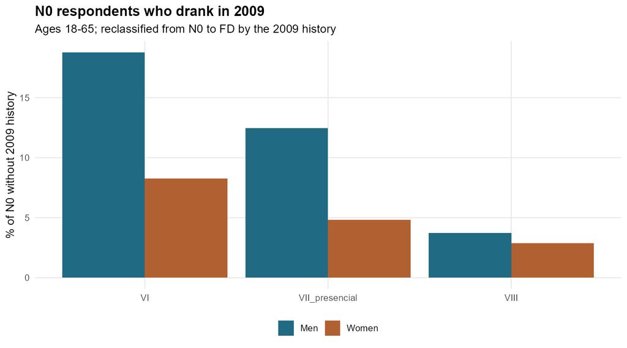

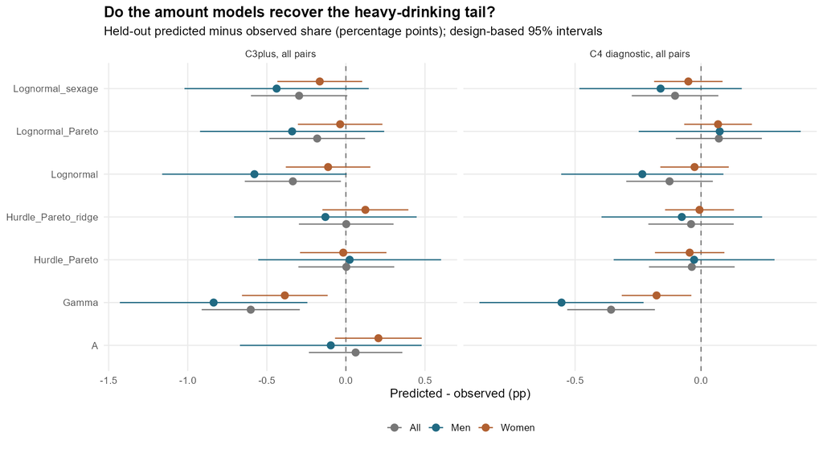

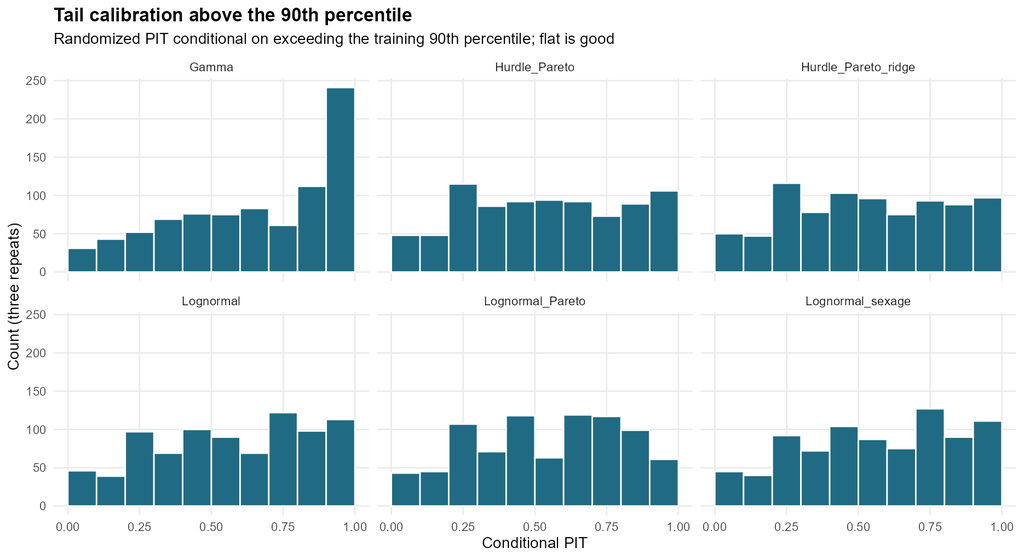

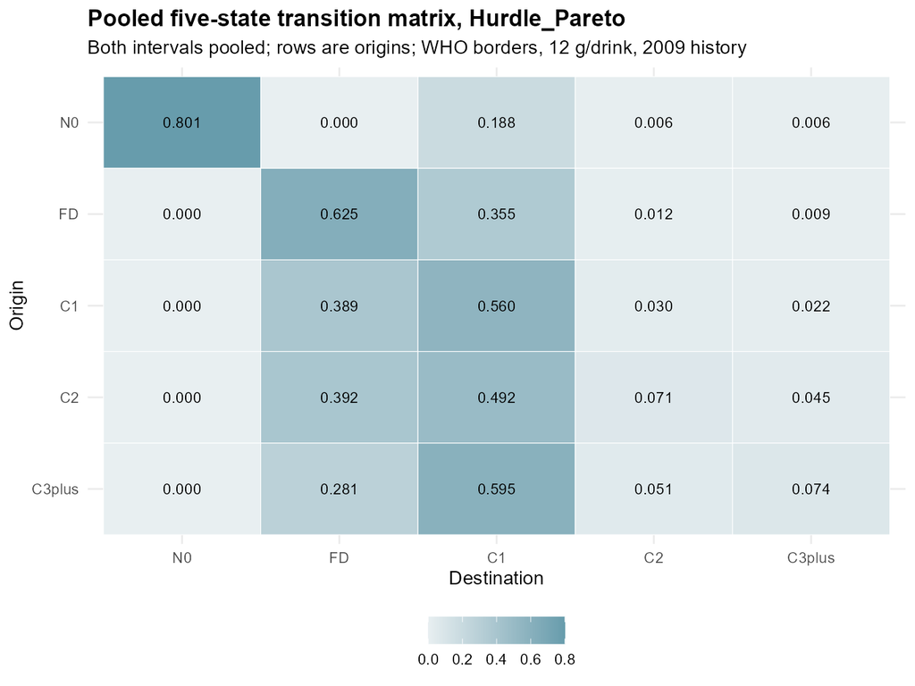

```
Elapsed: 0.03 minutes
```

```r
.t0 <- Sys.time()
ep_v4_plots()
cat(sprintf("Elapsed: %.2f minutes\n", as.numeric(difftime(Sys.time(), .t0, units = "mins"))))
```

## Reproducibility of version 4

The last cell proves that the v4 cells left every v1/v2 object unchanged, records the md5 of the source files, and stops if any check failed. The annual (continuous-time) layer for the five-state matrices is not part of version 4; it is the next step for the microsimulation.

**Show R code**

```r
.t0 <- Sys.time()
ep_v4_globals_after <- lapply(c("ep_W", "ep_risk", "ep_d", "ep_time", "ep_period_mass", "ep_v2_risk"), function(k) ep_v4_digest(get(k)))
ep_check(identical(ep_v4_globals_before, ep_v4_globals_after), "The v4 sections leave the v1/v2 objects unchanged")
src <- function(f) here::here("__andres_control", f)
ep_v4_sources <- data.frame(file = c("eps_markov_core.R", "eps_markov_v2_extra.R", "eps_markov_v4_extra.R", "eps_markov_v4_sections.R"),
  md5 = unname(tools::md5sum(src(c("eps_markov_core.R", "eps_markov_v2_extra.R", "eps_markov_v4_extra.R", "eps_markov_v4_sections.R")))))
ep_save(ep_v4_sources, "v4_source_md5")
ep_v4_checks_table <- data.frame(check = names(ep_checks), passed = unlist(ep_checks), row.names = NULL)
ep_save(ep_v4_checks_table, "v4_checks"); ep_save(ep_v4_cfg_table, "v4_configuration")
ep_show(ep_v4_sources, "Source files of this run (md5)", "Source files of this run (md5)")
ep_show(utils::tail(ep_v4_checks_table, 20), "Last checks recorded (all must be TRUE)", "Last checks recorded (all must be TRUE)")
stopifnot(all(ep_v4_checks_table$passed))
cat(sprintf("Elapsed: %.2f minutes\n", as.numeric(difftime(Sys.time(), .t0, units = "mins"))))
```

Source files of this run (md5)

| file | md5 |
| --- | --- |
| eps_markov_core.R | 297a91eb68281dd120994d450f9bac19 |
| eps_markov_v2_extra.R | 5abbe9d28bce172c2d8418a7be2e9c20 |
| eps_markov_v4_extra.R | acfd07c832ccd5974f2aafb5e0cb26d1 |
| eps_markov_v4_sections.R | cc39c04057f7acb6b5a4c6d9a6a16859 |

Last checks recorded (all must be TRUE)

| check | passed |
| --- | --- |
| v2: share followed within [0, 1] | TRUE |
| v2: completed pairs in the attrition table equal the v2 period masses | TRUE |
| v2: GLM odds ratios finite and inside their intervals | TRUE |
| v2: SuperLearner weights sum to one with finite cross-validated risks | TRUE |
| v2: SuperLearner probabilities of completed pairs lie in (0, 1] | TRUE |
| v2: every scheme reproduces the period masses | TRUE |
| v2: every available matrix row sums to one | TRUE |
| v2: SMD table covers every scheme, interval, origin state and covariate level | TRUE |
| v2: held-out calibration differences are finite | TRUE |
| v2: all recorded checks passed | TRUE |
| The JRT rule of ep_v4_cat equals the v1 ep_cat | TRUE |
| The WHO rule only moves men at exactly 60 g/day from C3plus to C2 | TRUE |
| v4 waves with the v4 switches off equal the v1 waves | TRUE |
| 2009 history changes origin labels only: identical pairs and destinations | TRUE |
| v4 pairs respect the history-state transition map | TRUE |
| With the IPW fixed, 2009 history leaves the drinker rows unchanged | TRUE |
| Every tail exponent was estimated within sex (no pooled fallback) | TRUE |
| Every v4 matrix row sums to one | TRUE |
| Structural zeros of the history map hold | TRUE |
| The v4 sections leave the v1/v2 objects unchanged | TRUE |

```
Elapsed: 0.00 minutes
```

## References / Referencias

- Calvo E et al. (2020). *Cross-country and historical variation in alcohol consumption among older men and women*. [Article, Table 2](https://pmc.ncbi.nlm.nih.gov/articles/PMC7585691/) and [supplement, Table S2](https://ars.els-cdn.com/content/image/1-s2.0-S0376871620303847-mmc1.docx).
- Calvo et al. (2021). [Alcohol transitions and harmonized history definitions](https://pmc.ncbi.nlm.nih.gov/articles/PMC8131222/).
- EPS official design: `_eps/notes/34_Informe Técnico EPS VIII Ronda.txt`, sections on longitudinal weights and sampling variance; `_eps/notes/16_EPS - Informe Metodologico-Muestreo, Atrición, Factores, Errores Muestrales.txt`.
- EPS V limitations: `_eps/docs/2012/Dossier_Resultados_VRondaEPS2012.pdf`, p. 23; [official documentation archive](https://www.previsionsocial.gob.cl/sps/download/estudios-previsionales/encuesta-de-proteccion-social/bases-de-datos-eps/instrucciones-bd-eps-2012.rar).
- Lumley, `survey`: [singleton strata](https://r-survey.r-forge.r-project.org/survey/exmample-lonely.html), [JKn replication](https://r-survey.r-forge.r-project.org/pkgdown/docs/reference/as.svrepdesign.html), [replicate variance](https://r-survey.r-forge.r-project.org/pkgdown/docs/reference/svrVar.html).
- JRT comparison: `jrt/simulacion/Alcohol Transitions FINAL.R`; harmonization source: `eps_alcohol_prevalencia_persistencia.ipynb`.
- Architecture for subsequent microsimulation integration: [Kilian et al. (2025), Lancet Public Health](https://pubmed.ncbi.nlm.nih.gov/40885207/), DOI 10.1016/S2468-2667(25)00165-3; [SIMAH release 0.1.1](https://doi.org/10.5281/zenodo.15641639). This notebook estimates Chilean transition components; it does not execute SIMAH or import US parameter values.
- Puka K, Buckley C, Mulia N, Lasserre AM, Rehm J, Probst C (2022). Behavioral stability of alcohol consumption and socio-demographic correlates of change among a nationally representative cohort of US adults. *Addiction* 118(1):61-70. https://doi.org/10.1111/add.16024
- Kilian C et al. (2025). Targeting alcohol use in high-risk population groups: a US microsimulation study of beverage-specific pricing policies. *Lancet Public Health*. https://doi.org/10.1016/S2468-2667(25)00165-3
- Ruiz-Tagle Maturana J, Roman Mella F, Castillo-Carniglia A (2026). Sex and age differences in alcohol-attributable mortality in Chile between 2008 and 2022. *Public Health in Practice* 11:100798. https://doi.org/10.1016/j.puhip.2026.100798